# Ordinary least-squares regressions: the basics

Marshall Worsham

12/06/2022

## What this tutorial covers

1. What ordinary least-squares (OLS) regressions do
2. How they work conceptually
3. How they work mathematically
4. Building a univariate OLS from scratch
5. Model interpretation
6. Challenge: practice with tree-ring and streamflow data

### 1. What ordinary least-squares (OLS) regressions do

At the very highest level, a regression is a kind of model, which means that it is a representation of something in the world. A bit more specifically, a regression describes the relationship(s) between a dependent variable and one or more independent variables, and it does so in a way that is simpler than the data themselves.

This tutorial focuses on ordinary least-squares (OLS) regression, which is the most familiar and straightforward form, but there are others: polynomial, logistic, partial least-squares, ridge and lasso, and generalized additive regressions, to name a few.

*Aside: You’ll often hear the terms “least-squares regression” or “linear regression” or “linear model” used to describe OLS regression; in most cases you can assume they’re interchangeable. You’ll also hear the terms “response”, “outcome”, or “y” used for dependent variables and “explanatory”, “predictor”, or “x” used for independent variables. Assume equivalence.*

The output of an OLS regression is an equation that describes a line in space. This “regression line” is the line that makes the vertical distance from the data points to the line itself as small as possible. In more technical language, it is the line that minimizes the *variance* between the data and the line itself. We’ll unpack what *variance* means in more detail shortly. Sometimes you’ll hear this line called the “line of best fit,” which makes sense in so far as the line fits all the points as closely as possible.

This line, or equivalently, its equation, is your model. The line-equation says that there is a relationship between the response ($y$) and the explanatory ($x$) variables. Specifically, it says that this relationship is linear, which means that for every one-unit increase in $x$, $y$ can be expected to increase by a precisely determined amount.

**tl/dr:** A regression is a simplified representation of some set of data. It yields an equation that describes a line, and this line is the one that minimizes the distance between all of the data points and itself. This line enables us to estimate the response, $y$, for a given value of $x$.

### 2. How OLS regressions work conceptually

Let’s start with a simple example, using just one response variable and one explanatory variable. We’ll use the Air Quality dataset, which comes built into R. This contains daily air quality measurements made in New York from May to Sep 1973, along with simultaneous measurements of solar radiation, wind speed, and temperature. We’ll take air quality (ozone concentration [O3] in parts per billion) as the response and see if we can find a linear relationship with wind speed using OLS.

Go ahead and load up the data and look at the first few lines.

```r
# Load the dataset
aq <- airquality

# View the first few lines of data
head(aq)
```

```
##   Ozone Solar.R Wind Temp Month Day
## 1    41     190  7.4   67     5   1
## 2    36     118  8.0   72     5   2
## 3    12     149 12.6   74     5   3
## 4    18     313 11.5   62     5   4
## 5    NA      NA 14.3   56     5   5
## 6    28      NA 14.9   66     5   6
```

```r
# Take out NA values
aq <- aq[rowSums(is.na(aq))==0,]
```

Run the block below to create a scatterplot of O3 concentration v. wind speed.

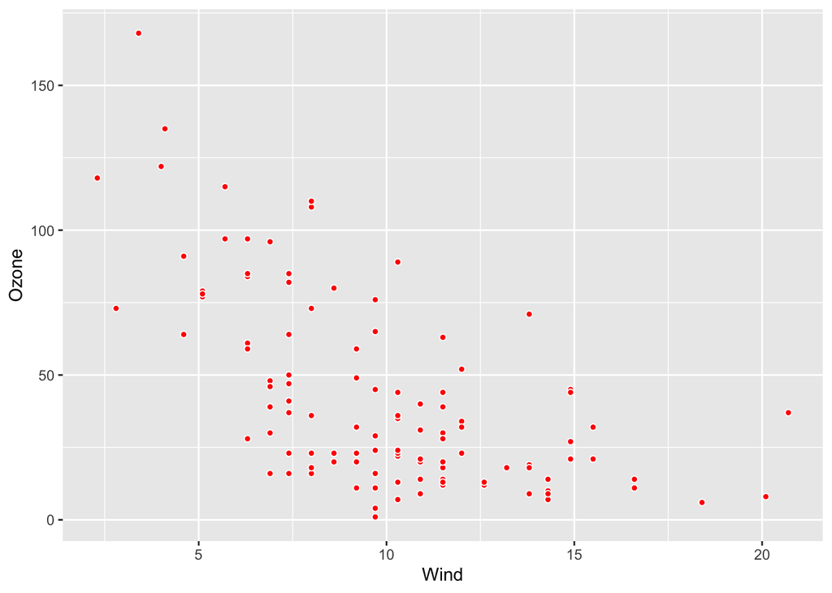

```r
# Plot the explanatory and response variables as a scatterplot
g <- ggplot(aq, aes(x=Wind, y=Ozone)) +
  geom_point(fill='red', color='white', pch=21)

g
```

It looks like there could be a relationship here, probably a negative one. You can imagine a lot of different lines that *could* potentially describe this relationship. Run the chunk below to visualize a few of them.

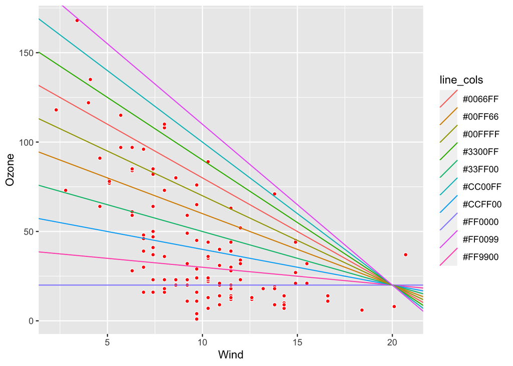

```r
# Generate a bunch of potential regression lines
line_slopes <- seq(0,-9)
line_intercepts <- seq(20, 200, 20)
line_cols <- rainbow(10)
si <- data.frame(line_slopes=line_slopes, line_intercepts=line_intercepts)

# Plot the lines on top of the data
g +
  geom_abline(data=si, aes(slope=line_slopes, intercept=line_intercepts, col=line_cols))
```

In fact, there are infinite such lines. But only one of them will minimize the distance between itself and all of the data points. This is the line we want to find. A statistician named Iñaki Úcar made this kind of fun dynamic graphic below to help visualize finding the best-fit line from an infinite set of possible lines.

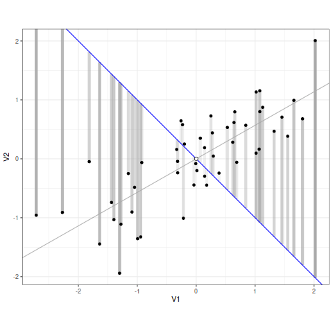

In this graphic, the blue line is a possible regression line. The vertical gray lines represent the vertical distance between a given data point and the regression line. As the blue line oscillates, the gray lines get shorter or longer (depending on which side of the pivot the data points are on). The blue line stabilizes once the *sum of the lengths of all of those gray lines* is at a minimum. This is the least-squares regression line.

Read back over this section and take a moment to internalize it. These are the conceptual keys to understanding OLS.

### 3. How they work mathematically

As we demonstrated in Section 2, when we fit a regression to a set of points, we’re assuming that there is some straight-line relationship between $y$ and $x$. The following equation describes that relationship:

$ŷ_i = \beta_0 + \beta_1X_i + \epsilon_i$

$\beta_0$ and $\beta_1$ are the equation’s coefficients. $\beta_0$ is the intercept—the place where the regression line crosses the y-axis, or the value of $ŷ$ when $x=0$. $\beta_1$ is the slope, or the amount by which $ŷ$ is estimated to increase when $x$ increases by 1. Sometimes you’ll hear these called “model parameters”; they mean the same thing. Intercept and slope are always the parameters of an OLS model. $X_i$ is your explanatory variable; it’s a vector (list) of values for $X$ from your data, where $i$ represents the $i$th observation. $\epsilon$ is something called random error, which we’ll get to shortly. $ŷ$ (usually said “y-hat”) is the estimated response, or the predicted value of your response variable.

Whatever you end up with for $\beta_0$ and $\beta_1$, the actual value of an observation in your dataset ($y_i$) is probably going to deviate from the value that your line predicts, ($\hat{y}_i$). The differences between the actual and predicted values are called random errors, or residuals. (Remember those gray lines in the animation above?)

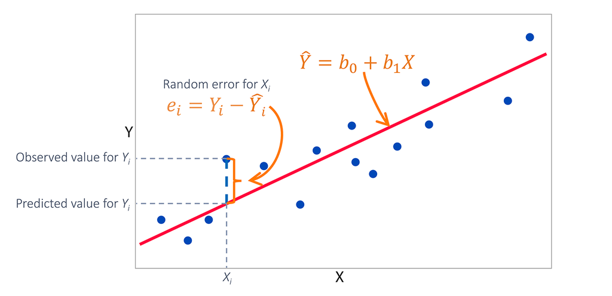

Except in the extremely unlikely case that all of your data sit perfectly on a straight line, you’re always going to have some random error. Like suffering, it’s something to accept. But remember that to fit a regression, we need to minimize the distance between all the data points and the line. This is the same thing as saying that we need to minimize the random error (or minimize the residuals).

When we fit a line through data, some of the errors will be positive and some will be negative. In other words, some of the actual values will be larger than their predicted value (they will fall above the line), and some of the actual values will be less than their predicted values (they’ll fall below the line).

If we added up all of these errors, the sum would be zero. How then can we measure overall error? We use a little trick: **we square the errors, sum them up, and find a line that minimizes this sum of squared errors.**

There’s some heavy-duty linear algebra and differentiation that can do this work and get us to the exact values of the coefficients $\beta_0$ and $beta_1$ (or what’s known as the “true model”). But, as it turns out, there are some shortcut equations that can get us to a very, very close approximation of the true model, and that’s usually good enough. We’ll call these approximate coefficients $\hat{\beta}_0$ and $\hat{\beta}_1$ (“beta-hat”) because we’re estimating their values.

The shortcut equation for finding $\hat{\beta}_0$ is:

$$\hat{\beta}_0 = \bar{y} - \hat{\beta}_1 \bar{x}$$

$\bar{y}$ is the mean of the $y$ values in your dataset. $\bar{x}$ is the mean of the $x$ values in your dataset.

$$\hat{\beta}_1 = \frac{\sum{^n_{i=1}(x_i-\bar{x})(y_i-\bar{y})}}{\sum{^n_{i=1}(x_i-\bar{x})^2}}$$

Here, $x_i$ and $y_i$ are individual observations in your dataset and $\bar{x}$ and $\bar{y}$ are the averages of $x$ and $y$, respectively.

In plain English, all you do to find $\hat{\beta}_1$ is:

1. subtract each observed $x$ from the mean of $x$ and multiply this difference by the difference between each observed $y$ and the mean of $y$; repeat for each value of $(x,y)$,
2. subtract each observed $x$ from the mean of $x$ and square it; repeat for each value of $x$
3. sum the results of (1) and divide them by the sum the results of (2).

### 4. Building a univariate OLS from scratch

It’s pretty straightforward to translate these equations into code. Once we do that, we can build a regression function that will allow us to run an OLS on any dataset. The end result of this section will be a function much like `lm()`, which is the basic linear model function that everyone uses from the {stats} package in R.

First, let’s translate those $\beta$ equations into code. (This is important! Spend some time with this, and make sure you know what is being computed at each step. Hint: take each step out of the function and print the results using some toy data for $x$ and $y$).

```r
ols <- function(x,y){
  #####
  # function get_betas takes two arguments, x and y
  # x: a single vector of values on one explanatory variable
  # y:  a single vector of values on one response variable
  # returns: a list of length two containing estimated values for b0 and b1
  #####

  # find the mean of x, but ignore NAs, which otherwise mess up the calculation
  mean_x = mean(x, na.rm=T)

  # find the mean of y, but ignore NAs, which otherwise mess up the calculation
  mean_y = mean(y, na.rm=T)

  # calculate b1
  # note that x and y here are the vectors we named as arguments to the functon
  b1 = sum((x-mean_x) * (y-mean_y), na.rm=T)/sum((x-mean_x)^2, na.rm=T)

  # calculate b0
  b0 = mean_y - b1 * mean_x

  # return a result
  return(list(b0=b0, b1=b1))
}
```

So now we have a way to estimate the coefficients. We can apply this function to our air quality dataset to estimate the least-squares regression line that describes the relationship between air quality and wind speed.

```r
# Define y
y = aq$Ozone

# Define x
x = aq$Wind

# Compute coefficients
betas <- ols(x, y)

# Print the coefficients
print(betas)
```

```
## $b0
## [1] 99.04128
##
## $b1
## [1] -5.728797
```

When you run this, your intercept ($\hat{\beta}_0$) should be about 99.0 and slope ($\hat{\beta}_1$) should be about -5.7. The equation, or model, that describes the linear relationship between air quality and wind speed is, therefore:

$$\hat{y} = 99.0 - 5.7X_i$$
To visualize how our line fits the data, we can add it to that scatterplot. How well does this match your expectations?

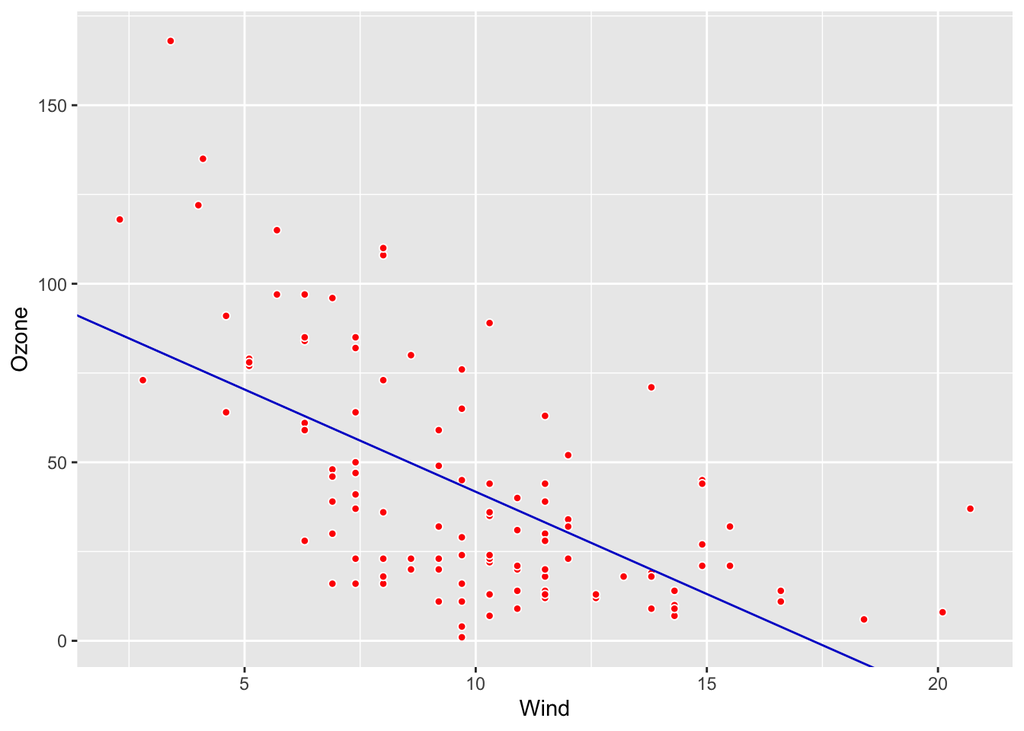

```r
# to add a regression line, use the call geom_abline(). this takes arguments for intercept in slope, for which we can just plug in the results from get_betas()
g + geom_abline(intercept=betas$b0, slope=betas$b1, col='blue3')
```

The line passes through the data about as you might expect, and there’s a more or less equal balance between data points falling above the line and falling below the line, so at first glance it looks like we produced a valid model. Great.